# HW_A3

## General Information

Fullname: LE Nhut Nam

Class: Applied Mathematics - 33/2023

Contact

- Email: nam.lnhut@gmail.com

```python
import numpy as np
import matplotlib.pyplot as plt

from math import comb
from collections import Counter

# Import the MarkovChain class from markovchain.py
from markovchain import MarkovChain
```

## Stochastic Process - Homework Assignment 03

### Exercise 01

A Markov chain $X_0, X_1, \dots$ on states $0, 1, 2$ has the transition probability matrix

$$ P = \begin{pmatrix} 0.1 & 0.2 & 0.7\\ 0.9 & 0.1 & 0.0\\ 0.1 & 0.8 & 0.1 \end{pmatrix} $$

and initial distribution $p_0 = P(X_0 = 0) = 0.3, p_1 = P(X_1 = 1) = 0.4, p_2 = P(X_2 = 2) = 0.3$. Determine $P(X_0 = 0, X_1 = 1, X_2 = 2)$

```python
# # Transition probability matrix
# P = np.array([
#     [0.1, 0.2, 0.7],
#     [0.9, 0.1, 0.0],
#     [0.1, 0.8, 0.1]
# ])
```

```python
# # Initial distribution
# p0, p1, p2 = 0.3, 0.4, 0.3
# v0 = np.array([p0, p1, p2])
```

The joint probability $P(X_0 = 0, X_1 = 1, X_2 = 2)$ can be written via conditional ones as follows,

$$ \begin{align} \begin{aligned} P(X_0 = 0, X_1 = 1, X_2 = 2) &= P(X_0 = 0) \cdot \frac{P(X_1 = 1, X_0 = 0)}{P(X_0 = 0)} \cdot \frac{P(X_2 = 2, X_1 = 1, X_0 = 0)}{P(X_1 = 1, X_0 = 0)} \\ &= P(X_0 = 0) \times P(X_1 = 1 \mid X_0 = 0) \times P(X_2 = 2 \mid X_1 = 1, X_0 = 0) \\ &= P(X_0 = 0) \times P(X_1 = 1 \mid X_0 = 0) \times P(X_2 = 2 \mid X_1 = 1) \text{ (Markov properties)}\\ &= 0.3 \times P_{0, 1} \times P_{1, 2}\\ &= 0.3 \times 0.2 \times 0.0 \\ &= 0.0 \end{aligned} \end{align} $$

### Exercise 02

A Markov chain $X_0, X_1, X_2, \dots$ has the transition probability matrix

$$ P = \begin{pmatrix} 0.7 & 0.2 & 0.1\\ 0.0 & 0.6 & 0.4\\ 0.5 & 0.0 & 0.5 \end{pmatrix} $$

Determine the conditional probabilities $P(X_2 = 1, X_3 = 1 \mid X_1 = 0)$ and $P(X_1 = 1, X_2 = 1 \mid X_0 = 0)$

Determine the conditional probabilities $P(X_2 = 1, X_3 = 1 \mid X_1 = 0)$, we have:

$$ \begin{align} \begin{aligned} P(X_2 = 1, X_3 = 1 \mid X_1 = 0) &= \frac{P(X_3 =1, X_2 = 1, X_1 = 0)}{P(X_1 = 0)} \\ &= \frac{P(X_3 =1, X_2 = 1, X_1 = 0)}{P(X_2 = 1, X_1 = 0)} \times \frac{P(X_2 = 1, X_1 = 0)}{P(X_1 = 0)}\\ &= P(X_3 = 1 \mid X_2 = 1, X_1 = 0) \times P(X_2 = 1 \mid X_1 = 0)\\ &= P(X_3 = 1 \mid X_2 = 1) \times P(X_2 = 1 \mid X_1 = 0)\\ &= P_{1, 1} \times P_{0, 1}\\ &= 0.6 \times 0.2\\ &= 0.12 \end{aligned} \end{align} $$

Determine the conditional probabilities $P(X_1 = 1, X_2 = 1 \mid X_0 = 0)$, we have:

$$ \begin{align} \begin{aligned} P(X_1 = 1, X_2 = 1 \mid X_0 = 0) &= P(X_1 = 1 \mid X_0 = 0) \times P(X_2 = 1 \mid X_1 = 1, X_0 = 0)\\ &= P(X_1 = 1 \mid X_0 = 0) \times P(X_2 = 1 \mid X_1 = 1)\\ &= P_{0, 1} \times P_{1, 1}\\ &= 0.2 \times 0.6\\ &= 0.12 \end{aligned} \end{align} $$

### Exercise 03

A Markov chain $X_0, X_1, X_2, \dots$ has the transition probability matrix

$$ P = \begin{pmatrix} 0.6 & 0.3 & 0.1\\ 0.3 & 0.3 & 0.4\\ 0.5 & 0.1 & 0.5 \end{pmatrix} $$

If it is known that the process starts in state $X_0 = 1$, determine the probability

$$ P(X_0 = 1,X_1 = 0, X_2 = 2) $$

### Exercise 04

A Markov chain $X_0, X_1, X_2, \dots$ has the transition probability matrix

$$ P = \begin{pmatrix} 0.1 & 0.1 & 0.8\\ 0.2 & 0.2 & 0.6\\ 0.3 & 0.3 & 0.4 \end{pmatrix} $$

Determine the conditional probabilities $P(X_1 = 1, X_2 = 1 \mid X_0 = 0)$ and $P(X_2 = 1, X_3 = 1 \mid X_1 = 0)$

Determine the conditional probabilities $P(X_1 = 1, X_2 = 1 \mid X_0 = 0)$, we have:

$$ \begin{align} \begin{aligned} P(X_1 = 1, X_2 = 1 \mid X_0 = 0) &= P(X_2 = 1 \mid X_1 = 1, X_0 = 0) \times P(X_1 = 1 \mid X_0 = 0)\\ &= P(X_2 = 1 \mid X_1 = 1) \times P(X_1 = 1 \mid X_0 = 0)\\ &= P_{1, 1} \times P_{0, 1}\\ &= 0.2 \times 0.1\\ &= 0.02 \end{aligned} \end{align} $$

Determine the conditional probabilities $P(X_2 = 1, X_3 = 1 \mid X_1 = 0)$, we have:

$$ \begin{align} \begin{aligned} P(X_2 = 1, X_3 = 1 \mid X_1 = 0) &= P(X_3 = 1 \mid X_2 = 1, X_1 = 0) \times P(X_2 = 1 \mid X_1 = 0)\\ &= P(X_3 = 1 \mid X_2 = 1) \times P(X_2 = 1 \mid X_1 = 0)\\ &= P_{1, 1} \times P_{0, 1}\\ &= 0.2 \times 0.1\\ &= 0.02 \end{aligned} \end{align} $$

### Exercise 05

A Markov chain $X_0, X_1, X_2, \dots$ has the transition probability matrix

$$ P = \begin{pmatrix} 0.3 & 0.2 & 0.5\\ 0.5 & 0.1 & 0.4\\ 0.5 & 0.2 & 0.3 \end{pmatrix} $$

and initial distribution $p_0 = 0.5$, and $p_1 = 0.5$. Determine the probabilities $P(X_0 = 1, X_1 = 1, X_2 = 0)$, and $P(X_1 = 1, X_2 = 1, X_3 = 0)$

### Exercise 06

A Markov chain $X_n$ on states $0, 1, 2$ has the transition probability matrix

$$ P = \begin{pmatrix} 0.1 & 0.2 & 0.7\\ 0.2 & 0.2 & 0.6\\ 0.6 & 0.1 & 0.3 \end{pmatrix} $$

```python
# Transition probability matrix
P = np.array([
    [0.1, 0.2, 0.7],
    [0.2, 0.2, 0.6],
    [0.6, 0.1, 0.3]
])
```

(a) Compute the two-step transition matrix $P^2$

```python
P2 =  np.linalg.matrix_power(P, 2)
P2
```

```
array([[0.47, 0.13, 0.4 ],
       [0.42, 0.14, 0.44],
       [0.26, 0.17, 0.57]])
```

(b) What is $P(X_3 = 1\mid X_1 = 0)$

$P(X_3 = 1\mid X_1 = 0) = P^2_{0, 1}$

```python
P2[0, 1]
```

```
0.13
```

(c) What is $P(X_3 = 1\mid X_0 = 0)$

```python
np.linalg.matrix_power(P, 3)[0, 1]
```

```
0.16
```

### Exercise 07

A particle moves among the states $0, 1, 2$ according to a Markov process whose transition probability matrix is

$$ P = \begin{pmatrix} 0.0 & 0.5 & 0.5\\ 0.5 & 0.0 & 0.5\\ 0.5 & 0.5 & 0.0 \end{pmatrix} $$

Let $X_n$ denote the position of the particle at the $n$-th move. Calculate

$$ P(X_n = 0\mid X_0 = 0) \text{ for} n = 0, 1, 2, 3, 4 $$

```python
# Transition probability matrix
P = np.array([
    [0.0, 0.5, 0.5],
    [0.5, 0.0, 0.5],
    [0.5, 0.5, 0.0]
])
```

```python
for i in range(0, 5):
    p =  np.linalg.matrix_power(P, 3)[0, 0]
    print(f"P(X_{i} = 0 | X_0 = 0) = {p}")
```

```
P(X_0 = 0 | X_0 = 0) = 0.25
P(X_1 = 0 | X_0 = 0) = 0.25
P(X_2 = 0 | X_0 = 0) = 0.25
P(X_3 = 0 | X_0 = 0) = 0.25
P(X_4 = 0 | X_0 = 0) = 0.25
```

### Exercise 08

A Markov chain $X_0, X_1, X_2, \dots$ has the transition probability matrix

$$ P = \begin{pmatrix} 0.7 & 0.2 & 0.1\\ 0.0 & 0.6 & 0.4\\ 0.5 & 0.0 & 0.5 \end{pmatrix} $$

Determine the conditional probabilities $P(X_3 = 1 \mid X_1 = 0)$, and $P(X_2 = 1 \mid X_0 = 0)$

```python
# Transition probability matrix
P = np.array([
    [0.7, 0.2, 0.1],
    [0.0, 0.6, 0.4],
    [0.5, 0.0, 0.5]
])
```

```python
print(f"P(X_{3} = 1 | X_1 = 0) = { np.linalg.matrix_power(P, 2)[0, 1]}")
```

```
P(X_3 = 1 | X_1 = 0) = 0.26
```

```python
print(f"P(X_{2} = 1 | X_1 = 0) = { np.linalg.matrix_power(P, 1)[0, 1]}")
```

```
P(X_2 = 1 | X_1 = 0) = 0.2
```

### Exercise 09

A Markov chain $X_0, X_1, X_2, \dots$ has the transition probability matrix

$$ P = \begin{pmatrix} 0.6 & 0.3 & 0.1\\ 0.3 & 0.3 & 0.4\\ 0.4 & 0.1 & 0.5 \end{pmatrix} $$

If it is known that the process starts in state $X_0 = 1$, determine the probability $P(X_2 = 2)$

$P(X_0 = 1) = 1$

### Exercise 10

A Markov chain $X_0, X_1, X_2, \dots$ has the transition probability matrix

$$ P = \begin{pmatrix} 0.1 & 0.1 & 0.8\\ 0.2 & 0.2 & 0.6\\ 0.3 & 0.3 & 0.4 \end{pmatrix} $$

Determine the conditional probabilities $P(X_3 = 1 \mid X_1 = 0)$, and $P(X_2 = 1 \mid X_0 = 0)$

```python
# Transition probability matrix
P = np.array([
    [0.1, 0.1, 0.8],
    [0.2, 0.2, 0.6],
    [0.3, 0.3, 0.4]
])
```

```python
print(f"P(X_{3} = 1 | X_1 = 0) = {np.linalg.matrix_power(P, 2)[0, 1]}")
```

```
P(X_3 = 1 | X_1 = 0) = 0.27
```

```python
print(f"P(X_{3} = 1 | X_1 = 0) = {np.linalg.matrix_power(P, 1)[0, 1]}")
```

```
P(X_3 = 1 | X_1 = 0) = 0.1
```

### Exercise 11

A Markov chain $X_0, X_1, X_2, \dots$ has the transition probability matrix

$$ P = \begin{pmatrix} 0.3 & 0.2 & 0.5\\ 0.5 & 0.1 & 0.4\\ 0.5 & 0.2 & 0.3 \end{pmatrix} $$

and initial distribution $p_5 =0.5$, and $p_1 = 0.5$. Determine the probabilities $P(X_2 = 0)$, and $P(X_3 = 0)$.

### Exercise 12

Draw the state transition diagrams and classify the states of the Markov chains with the following transition probability matrices

$$ f_{00} = \sum_{m = 1}^\infty f_{00}^{m} $$

(a)

$$ P = \begin{pmatrix} 0.0 & 0.5 & 0.5\\ 0.5 & 0.0 & 0.5\\ 0.5 & 0.5 & 0.0 \end{pmatrix} $$

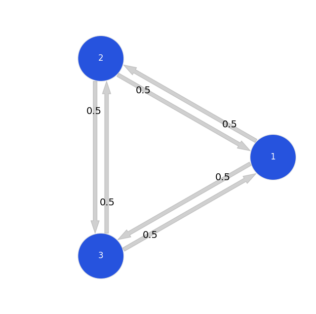

```python
P = np.array([[0.0, 0.5, 0.5], [0.5, 0.0, 0.5], [0.5, 0.5, 0.0]]) # Transition matrix
mc = MarkovChain(P, ['1', '2', '3'])
mc.draw()
```

(b)

$$ P = \begin{pmatrix} 0.0 & 0.0 & 0.5 & 0.5\\ 1 & 0.0 & 0.0 & 0.0\\ 0.0 & 1 & 0.0 & 0.0\\ 0.0 & 1 & 0.0 & 0.0\\ \end{pmatrix} $$

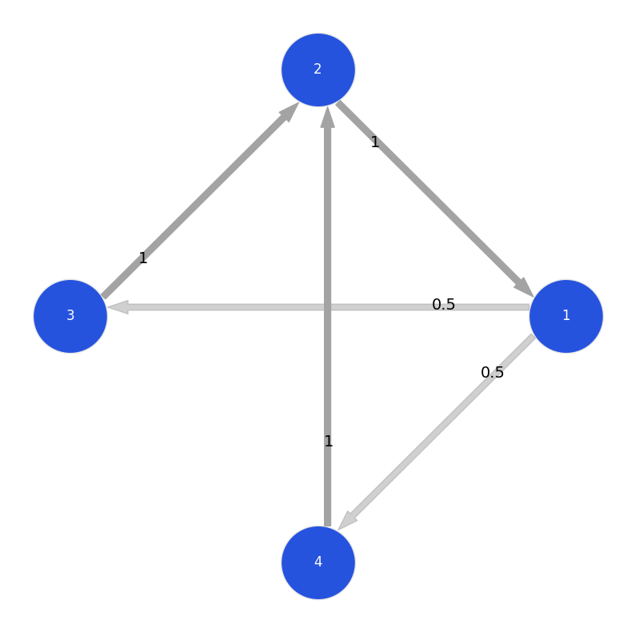

```python
P = np.array([[0.0, 0.0, 0.5, 0.5], [1, 0.0, 0.0, 0.0], [0.0, 1, 0.0, 0.0], [0.0, 1, 0.0, 0.0]]) # Transition matrix
mc = MarkovChain(P, ['1', '2', '3', '4'])
mc.draw()
```

(c)

$$ P = \begin{pmatrix} 0.3 & 0.4 & 0.0 & 0.0 & 0.3\\ 0.0 & 1 & 0.0 & 0.0 & 0.0\\ 0.0 & 0.0 & 0.0 & 0.6 & 0.4\\ 0.0 & 0.0 & 0.0 & 0.0 & 1\\ 0.0 & 0.0 & 1 & 0.0 & 0.0\\ \end{pmatrix} $$

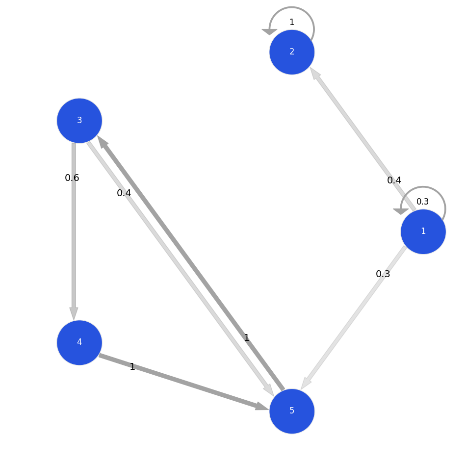

```python
P = np.array([[0.3, 0.4, 0.0, 0.0, 0.3], [0.0, 1, 0.0, 0.0, 0.0], [0.0, 0.0, 0.0, 0.6, 0.4], [0.0, 0.0, 0.0, 0.0, 1], [0.0, 0.0, 1, 0.0, 0.0]]) # Transition matrix
mc = MarkovChain(P, ['1', '2', '3', '4', '5'])
mc.draw()
```

### Exercise 13

Consider a Markov chain with state space $\{0, 1\}$ and transition probability matrix

$$ \begin{bmatrix} 1 & 0\\ 1/2 & 1/2 \end{bmatrix} $$

(a) Show that the state 0 is recurrent

(b) Show that state 1 is transient.

### Exercise 14

Consider a Markov chain with state space $\{0, 1, 2\}$, and transition probability matrix

$$ \begin{bmatrix} 0 & 1/2 & 1/2\\ 1 & 0 & 0\\ 1 & 0 & 0\\ \end{bmatrix} $$

Show that state 0 is periodic with period 2.

### Exercise 15

A Markov chain $\{X_n, n \leq 0\}$ with states 0, 1, 2, has the transition probability matrix

$$ \begin{bmatrix} 1/2 & 1/3 & 1/6\\ 0 & 1/3 & 2/3\\ 1/2 & 0 & 1/2\\ \end{bmatrix} $$

(a) $P(X_0 = 0) = P(X_0 = 1) = 1/4$, find $\mathbb{E}(X_3)$

We have $P(X_0 = 0) = P(X_0 = 1) = 1/4$, so $P(X_0 = 2) = 1 - 2 * 1/4 = 1/2$. So vector intitial probability is

$$ \mathbf{\alpha} = [1/4, 1/4, 1/2] $$

$$ P(X_3 = j) = \sum_{i=0}^{\infty}P_{ij}^{(3)}\alpha_i $$

```python
alpha = np.array([0.25, 0.25, 0.5])
```

```python
P = np.array([[1/2, 1/3, 1/6], [0, 1/3, 2/3], [1/2, 0, 1/2]])
```

```python
alpha @ np.linalg.matrix_power(P, 3)
```

```
array([0.41 , 0.199, 0.391])
```

(b) Find the invariant probability $\bar{\pi}$

### Exercise 16

Consider a gambler who at each play of the game has probability p of winning one unit and probability $q = 1 − p$ of losing one unit. Let $p_i, i = 0, 1, \dots, N$, denote the probability that, starting with $i$, the gambler’s fortune will eventually reach $N$. Assuming that successive plays of the game are independent

(a) What is the probability that, starting with $i$ units, the gambler’s fortune will reach N before reaching 0?

(b) Suppose Nam and Dong decide to flip pennies; the one coming closest to the wall wins. Dong, being the better player, has a probability 0.6 of winning on each flip.

(i) If Dong starts with five pennies and Nam with ten, what is the probability that Dong will wipe Nam out?

(ii) What if Dong starts with 10 and Nam with 20?

### Exercise 17

Three white and three black balls are distributed in two urns in such a way that each contains three balls. We say that the system is in state $i$, $i = 0, 1, 2, 3$, if the first urn contains $i$ white balls. At each step, we draw one ball from each urn and place the ball drawn from the first urn into the second, and conversely with the ball from the second urn. Let $X_n$ denote the state of the system after the $n$-th step.

(a) Explain why $\{X_n , n = 0, 1, 2, \dots\}$ is a Markov chain and calculate its transition probability matrix.

The state of the system is defined by the number of white balls in the first box. There are four states

- First: Urns-1[3 black, 0 white] --- Urns-2[0 black, 3 white]
- Second: Urns-1[2 black, 1 white] --- Urns-2[1 black, 2 white]
- Third: Urns-1[1 black, 2 white] --- Urns-2[2 black, 1 white]
- Last: Urns-1[0 black, 3 white] --- Urns-2[3 black, 0 white]

=> discrete time Markov chain.

Its transition probability matrix

$$ P = \begin{bmatrix} &\mathbf j&\mathbf0&\mathbf1&\mathbf2&\mathbf3\\ \mathbf i&\\ \mathbf0&&0&1&0&0\\ \mathbf1&&\frac19&\frac49&\frac49&0\\ \mathbf2&&0&\frac49&\frac49&\frac19\\ \mathbf3&&0&0&1&0 \end{bmatrix} $$

$\mathbf i$ stands for the state the system actually is at, and $\mathbf j$ stands for the state the system is to jump to.

Considering

$$ P_{2, 1} = \frac{4}{9} $$

Because we need select either of the white balls (2/ 3) from the first box and white ball in the second box (1/ 3) or the black balls (2/ 3) from the second box and black ball in the first box (1/ 3); these events are indepdent. So:

$$ P_{2, 1} = \frac{2}{3} \times \frac{2}{3} = \frac{4}{9} $$

(b) Determine the limiting probabilities $\pi_j$

We find the stationary probabilities by solving

$$ \pi_j = \sum_{i = 0}^{\infty}\pi_iP_{ij}, j >0 $$ where $\sum_{j=0}^{\infty}\pi_j = 1$

In this case:

```python
A = np.array([[-1, 1/9, 0, 0], [1, -5/9, 4/9, 0], [0, 4/9, -5/9, 4/9], [1, 1, 1, 1]])
b = np.array([0, 0, 0, 1])
result = np.linalg.solve(A, b)
print(f"By solving the system of equations, we get \pi_0 = {result[0]}, \pi_1 = {result[1]}, \pi_2 = {result[2]}, \pi_3 = {result[3]}")
```

```
By solving the system of equations, we get \pi_0 = 0.04705882352941175, \pi_1 = 0.42352941176470577, \pi_2 = 0.4235294117647058, \pi_3 = 0.10588235294117665
```

### Exercise 18

Suppose that coin 1 has probability 0.7 of coming up heads, and coin 2 has probability 0.6 of coming up heads. If the coin flipped today comes up heads, then we select coin 1 to flip tomorrow, and if it comes up tails, then we select coin 2 to flip tomorrow. If the coin initially flipped is equally likely to be coin 1 or coin 2.

Giả sử đồng xu 1 có xác suất xuất hiện mặt ngửa là 0,7 và đồng xu 2 có xác suất xuất hiện mặt ngửa là 0,6. Nếu hôm nay lật đồng xu là mặt ngửa thì ta chọn đồng xu 1 để tung vào ngày mai, còn nếu lật đồng xu là mặt ngửa thì ta chọn đồng xu 2 để tung vào ngày mai. Nếu đồng xu được lật ban đầu thì khả năng là đồng xu 1 hoặc đồng xu 2 như nhau.

$\{X_n, n \geq\}$ is Markov chain where $X_i$ is a random variable donate the label of the coin that is flipped on the $n$-th day after the initial flip.

The state of the system is defined by coin flipping, flipping coin 1 or flipping coin 2:

Transition matrix:

$$ P = \begin{bmatrix} &\mathbf j&\mathbf0&\mathbf1\\ \mathbf i&\\ \mathbf0&&0.7&0.3\\ \mathbf1&&0.6&0.4\\ \end{bmatrix} $$

(a) What is the probability that the coin flipped on the third day after the initial flip is coin 1?

```python
P = np.array([
    [0.7, 0.3],
    [0.6, 0.4],
])
```

```python
P3 = np.linalg.matrix_power(P, 3)
```

```python
(P3[0, 0] + P3[1, 0]) / 2
```

```
0.6664999999999999
```

(b) Suppose that the coin flipped on Monday comes up heads. What is the probability that the coin flipped on Friday of the same week also comes up heads?

```python
np.linalg.matrix_power(P, 4)
```

```
array([[0.667, 0.333],
       [0.667, 0.333]])
```

```python
np.linalg.matrix_power(P, 4)[0, 0]
```

```
0.6667
```

### Exercise 19

Coin 1 comes up heads with probability 0.6 and coin 2 with probability 0.5. A coin is continually flipped until it comes up tails, at which time that coin is put aside and we start flipping the other one.

Define state 0 to flip coin number one, and state 1 to flip coin number two. So the transition matrix can be written as:

$$ P = \begin{bmatrix} &\mathbf j&\mathbf0&\mathbf1\\ \mathbf i&\\ \mathbf0&&0.6&0.4\\ \mathbf1&&0.5&0.5\\ \end{bmatrix} $$

(a) What proportion of flips use coin 1?

We find the stationary probabilities by solving

$$ \pi_j = \sum_{i = 0}^{\infty}\pi_iP_{ij}, j >0 $$ where $\sum_{j=0}^{\infty}\pi_j = 1$

In this case:

\begin{cases} 0.6\pi_0 + 0.5\pi_1 = \pi_0\\ 0.4\pi_0 + 0.5\pi_1 = \pi_1\\ \pi_0 + \pi_1 =1 \end{cases}

```python
A = np.array([[-0.4, 0.5], [1, 1]])
b = np.array([0, 1])
result = np.linalg.solve(A, b)
print(f"By solving the system of equations, we get \pi_0 = {result[0]}, \pi_1 = {result[1]}")
```

```
By solving the system of equations, we get \pi_0 = 0.5555555555555556, \pi_1 = 0.4444444444444445
```

This means that we will use coin 1 in 0.5555555555555556 of the flips.

(b) If we start the process with coin 1 what is the probability that coin 2 is used on the fifth flip?

```python
P = np.array([[0.6, 0.4], [0.5, 0.5]])

np.linalg.matrix_power(P, 4)
```

```
array([[0.556, 0.444],
       [0.556, 0.445]])
```

```python
np.linalg.matrix_power(P, 4)[0, 1]
```

```
0.4444
```

### Exercise 20

In a good weather year the number of storms is Poisson distributed with mean 1; in a bad year it is Poisson distributed with mean 3. Suppose that any year’s weather conditions depends on past years only through the previous year’s condition. Suppose that a good year is equally likely to be followed by either a good or a bad year, and that a bad year is twice as likely to be followed by a bad year as by a good year. Suppose that last year-call it year 0-was a good year.

Let

\begin{cases} X_n = 0, \text{ year } n \text{ is good }\\ X_n = 1, \text{ year } n \text{ is bad } \end{cases}

$S_n$ = number of storms in year $n$

There are two states

- A good year is equally likely to be followed by a good or bad year. So $P_{0,0} = 1/2$, and $P_{0, 1} = 1/2$
- A bad year is twice as likely to be followed by a bad year as a good year. So $P_{1,0} = 1/3$, and $P_{1,1} = 2/3$

Transition matrix:

$$ \mathcal{P} = \begin{bmatrix} &\mathbf j&\mathbf0&\mathbf1\\ \mathbf i&\\ \mathbf0&&1/2&1/2\\ \mathbf1&&1/3&2/3\\ \end{bmatrix} $$

Suppose that last year-call it year 0-was a good year. So $v_0 = [1, 0]$

```python
P = np.array([[1/2, 1/2], [1/3, 2/3]])
```

```python
v0 = np.array([1, 0])
```

```python
mean_good = 1
mean_bad = 3
```

(a) Find the expected total number of storms in the next two years (that is, in years 1 and 2).

```python
v1 = v0 @ np.linalg.matrix_power(P, 1)
v1
```

```
array([0.5, 0.5])
```

```python
v2 = v0 @ np.linalg.matrix_power(P, 2)
v2
```

```
array([0.417, 0.583])
```

$S_n$ is Poisson with mean 1 in a good year and mean 3 in a bad year.

$$ \mathbb{E}[S_1] = \mathbb{E}[S_1 \mid X_1 = 0]P[X_1 = 0] + \mathbb{E}[S_1 \mid X_1 = 1]P[X_1 = 1] $$

```python
ES_1 = mean_good * v1[0] + mean_bad * v1[1]
ES_1
```

```
2.0
```

```python
ES_2 = mean_good * v2[0] + mean_bad * v2[1]
ES_2
```

```
2.1666666666666665
```

```python
ES1_2 = ES_1 + ES_2
ES1_2
```

```
4.166666666666666
```

(b) Find the probability there are no storms in year 3.

```python
v3 = v0 @ np.linalg.matrix_power(P, 3)
v3
```

```
array([0.403, 0.597])
```

(c) Find the long-run average number of storms per year.

\begin{cases} \pi_0 = \frac{1}{2}\pi_0 + \frac{1}{3}\pi_1\\ \pi_1 = \frac{1}{2}\pi_0 + \frac{2}{3}\pi_1\\ \end{cases}

```python
A = np.array([[-1/2, 1/3], [1, 1]])
b = np.array([0, 1])
result = np.linalg.solve(A, b)
result
```

```
array([0.4, 0.6])
```

\begin{align} \begin{aligned} \lim_{n\rightarrow \infty}\mathbb{E}[S_n] &= \lim_{n\rightarrow \infty}\mathbb{E}[S_n \mid X_n = 0]P[X_n = 0] + \mathbb{E}[S_n \mid X_n = 1]P[X_n = 1] \\ &= \lim_{n\rightarrow \infty}\mathbb{E}[S_n \mid X_n = 0]\pi_0 + \mathbb{E}[S_n \mid X_n = 1]\pi_1 \\ &= 1 \times 0.4 + 3 \times 0.6\\ &= 2.2 \end{aligned} \end{align}

### Exercise 21

Consider three urns, one colored red, one white, and one blue. The red urn contains 1 red and 4 blue balls; the white urn contains 3 white balls, 2 red balls, and 2 blue balls; the blue urn contains 4 white balls, 3 red balls, and 2 blue balls. At the initial stage, a ball is randomly selected from the red urn and then returned to that urn. At every subsequent stage, a ball is randomly selected from the urn whose color is the same as that of the ball previously selected and is then returned to that urn. In the long run, what proportion of the selected balls are red? What proportion are white? What proportion are blue?

Xem xét ba bình, một bình màu đỏ (bình đỏ), một bình màu trắng (bình trắng), và một bình màu xanh (bình xanh). Bình đỏ chứa 1 bóng đỏ và 4 bóng xanh; bình trắng chứa 3 bóng trắng, 2 bóng đỏ và 2 bóng xanh; bình xanh chứa 4 bóng trắng, 3 bóng đỏ và 2 bóng xanh. Ở bước khởi tạo, một bóng được chọn ngẫu nhiên từ bình đỏ và quay trở lại bình đó. Ở mỗi bước sau, một bóng được chọn ngẫu nhiên từ bình mà nó cùng màu với bóng được chọn trước đó và sau đó được trả về bình đó. Trong khoảng thời gian dài, tỷ lệ chọn được những bóng màu đỏ là bao nhiêu? Tỷ lệ bóng trắng? Tỷ lệ bóng xanh?

Its transition probability matrix

$$ P = \begin{bmatrix} &\mathbf j&\mathbf0&\mathbf1&\mathbf2\\ \mathbf i&\\ \mathbf0&&1/5&0&4/5\\ \mathbf1&&2/7&3/7&2/7\\ \mathbf2&&1/3&4/9&2/9\\ \end{bmatrix} $$

```python
A = np.array([[2/7, -4/7, 2/7], [1/3, 4/9, -7/9], [1, 1, 1]])
b = np.array([0, 0, 1])
result = np.linalg.solve(A, b)
print(f"By solving the system of equations, we get \pi_0 = {result[0]}, \pi_1 = {result[1]}, \pi_2 = {result[2]}")
```

```
By solving the system of equations, we get \pi_0 = 0.3333333333333334, \pi_1 = 0.3333333333333333, \pi_2 = 0.3333333333333333
```